# Project Report: Team Saturn

Team name

Author

Kaitlyn Hung, Amy Wang, Anastasia Wei, & Lila Wells

Published

March 13, 2023

Abstract

*A hospital’s ability to release healthier patients is an established metric for its success. More recently, a hospital’s success has also been measured by its readmission rate– or the extent to which patients are being retreated within 30 days of their initial inpatient stay. Readmissions signal a breakdown in care that negatively impact a patient’s health and wallet, as well as hospital finances. Thus, patients, healthcare providers, and healthcare administrators have an interest in decreasing readmissions. By analyzing data compiled from 130 U.S. hospitals between 1999 and 2008, we explore the relationship between the factors associated with a patient’s initial hospital stay and their likelihood of readmission. We implement several techniques (SMOTENC, undersampling, OLS, cross-validation) and logistic regression to answer this question–optimizing model recall, precision, and False Negative Rate. We find that a patient’s age, time spent in hospital, and number of inpatient visits increase their odds of readmission. Additionally, patients with many medication changes have decreased odds of readmission. Thus, We recommend that our stakeholders be hyper-vigilant with patients who are older, spend significant time in the hospital, and have frequent inpatient stays, as these patients have the highest odds of being readmitted to hospital.*.

## 1 Background / Motivation

A hospital’s ability to release happier and healthier patients is an established metric for its success as an institution. But more recently, a hospital’s success has also been measured by its readmission rate: or the extent to which patients are being retreated in a hospital within 30 days of their initial inpatient hospital stay. Hospital readmissions are associated with worse patient outcomes and high financial strains on hospitals and their administration [1]. And the cost is high; readmissions often double the cost of a patient’s care (both for the patients themselves and the hospital treating them. As Mcllvennan et al. notes, approximately “20% of all Medicare discharges have a readmission within 30 days” and, of those, an estimated 12% are potentially avoidable [1], [2]. These often avoidable readmissions (due to hasty and/or incomplete care) are not only costly to the hospital and patient, but also potentially life-threatening depending on a given patient’s ailment.

As such, determining what factors affect a patient’s likelihood of being readmitted to the hospital is of paramount importance for patients, their physicians, and hospital administration alike. As our group is interested in medicine and passionate about improved and equitable health outcomes, we asked ourselves: **What if we could identify the relationship between the factors associated with a patient’s initial stay and their likelihood of being readmitted?** We imagine that, equipped with this information, hospital staff and patients could work together to adjust patient care plans and avoid readmissions.

We propose to address this problem using diabetes as a case study. Diabetes is an ailment that affects approximately 537 million individuals worldwide, regardless of age [3]. Though individuals with diabetes must carefully maintain their diet, exercise, and other living conditions in order to manage their illness, hospitalizations are not rare. In one study, “25 percent of patients with Type 1 diabetes and 30 percent with Type 2 diabetes had a hospital admission during one year” [4]. The abundance of information known about these hospital admissions provides a ripe opportunity to build and test a model to predict readmission, simultaneously filling a need for diabetes patients, healthcare workers, and hospital administrators alike.

## 2 Problem Statement

To approach our analysis, we first articulated a question to guide our modeling process: **What is the relationship between the different factors associated with a patient’s hospital stay and their likelihood of being readmitted to that hospital within 30 days?**

In this question, we are most interested in *identifying the relationship* between predictors (here, factors associated with a patient’s hospital stay) and a response (whether a patient is readmitted or not). Thus, our model is mainly concerned with **inference.**

## 3 Data sources

In our project, we used a dataset entitled “Diabetes 130-US hospitals for years 1999-2008 dataset” from the UCI Machine Learning Repository. The dataset can be accessed [here](https://archive.ics.uci.edu/ml/datasets/Diabetes+130-US+hospitals+for+years+1999-2008#).

All data was collected between 1999 and 2008 from over 130 US hospitals and related care centers. The dataset contains over 10,000 entries, each corresponding to a patient with either Type 1 or Type 2 diabetes.

Observations had to satisfy the following criteria to be included in this dataset:

1. The patient must have had an inpatient encounter (i.e., they must have been admitted to the hospital)
2. The incident must have been a diabetic encounter (i.e., the patient had to have been a diabetic)
3. The length of the patient’s hospital stay had to have been between 1 and 14 days
4. Laboratory tests had to have been administered during the patient’s initial hospital stay
5. The patient must have received medications during their hospital stay

We chose to use this dataset because it contains our variable of interest (whether a patient was readmitted or not) along with ~46 potential predictors to use to fit the model. This dataset is extremely robust and comprehensive, including information on over 10,000 patients in the US across a decade. This broad and comprehensive data increases the generalizability of our study’s findings. Its number of predictors also allows us to approach our problem from multiple perspectives: (1) the patient’s characteristics, (2) their hospital stay and medical history, and (3) the treatments administered to them.

## 4 Stakeholders

We have identified three stakeholder groups that would benefit from our analysis: (1) diabetes patients and their loved ones; (2) hospital staff involved in direct patient care and; (3) hospital administrators and those who have an interest in reducing the financial waste in healthcare (i.e. Medicaid).

### 4.1 Diabetic Patients and Their Loved Ones

Our first stakeholder group is diabetes patients and their loved ones. For diabetes patients and their loved ones, the results of our project could provide them insight into factors impacting the diabetic’s continued risks of illness and subsequent hospital readmissions. A hospital stay can be emotionally and financially stressful for a diabetic patient and their family. Hospital readmissions then exacerbate this toll on patients by subjecting them to more inpatient stays. Further, as readmissions are associated with worse patient health outcomes, it is likely that diabetic who are readmitted will thus be readmitted again, worsening the burden to both their health and finances [3]. Understanding what factors contribute to hospital readmissions may empower patients and their families to take a more active and focused role in improving their health outcomes.

For instance, if a patient was aware that they had certain risk factors associated with a greater likelihood of readmission, they may direct more time and resources towards alleviating these factors and advocating for their health. Patients and their family could be more vigilant toward early warning-signs and communicate proactively with their physician or healthcare provider about prevention. Overall, this knowledge can empower patients with diabetes to direct their efforts towards areas that most affect their health outcome.

### 4.2 Hospital Staff Involved in Direct Patient Care

Our second stakeholder group include hospital staff and physicians involved in direct patient care. These stakeholders are directly charged with overseeing the healthcare plans of diabetic patients. Thus, they are morally, professionally, and financially invested in giving their patients the best possible care to improve their health outcomes. With a better understanding of factors that impact the likelihood of a diabetic patient’s readmission, healthcare workers may adjust their administration of care during the patient’s initial hospital visit.

For instance, if a patient has an elevated risk of being readmitted, their doctor may adjust the patient’s healthcare plan to focus on and alleviate that risk. The patient thus will likely have better health outcomes, and their risk of returning to the hospital within 30 days of being released (the criteria for a readmission) would be avoided.

This project may thus inform healthcare workers about which of their patients require the most vigilant and preventative interventions. Physicians, equipped with this knowledge, may then help to lower both the morbidity and mortality for diabetics in their care.

### 4.3 Hospital Administrators and Medicaid

Our third and final stakeholder group consists of hospital administrators and those with an active interest in reducing the cost of healthcare, like Medicaid providers. Hospital readmissions are financially costly to the healthcare system. The Affordable Care Act incentivizes the reduction of hospital admissions by financially penalizing hospitals with high readmission rates [4]. Penalties may include reduced payments to hospitals with excessive readmissions. In 2021, these penalties are projected to cost hospitals $521 million dollars [4]. As such, hospital administrators may have a vested financial interest in identifying factors that most contribute to an increased likelihood of returning to the hospital. By identifying such factors, administrators can allocate hospital resources towards addressing them, so that patient health outcomes are improved, readmissions decrease, and their hospital avoids suffering related financial penalties.

## 5 Data quality check / cleaning / preparation

### 5.1 Distribution of Categorical Variables

See **Appendix A, Tables 1-7** for distributions of the categorical variables used in our analysis: (1) changes in medications (`change`), (2) use of diabetic mediations (`diabetesMed`), (3) primary diagnosis (`diag_1`), (4) secondary diagnosis (`diag_2`), (5) admission source, like the emergency room or from a routine visit (`admission_source_id`), (6) discharge type (i.e., to ones home, to further care, etc.) (`discharge_disposition_id`) and (7) type of admission (`admission_type_id`). All categorical variables had no missing values.

After visualizing the distribution of these variables, we noted that the variables for primary and secondary diagnoses (`diag_1` and `diag_2`) had 717 and 749 levels, respectively. Thus, these variables would likely benefit from being binned into larger categories representative of the diagnosis type (i.e. circulatory, respiratory, etc.) to aid in our later model’s interpretability.

### 5.2 Distribution of Continuous Variables

See **Appendix A, Tables 8-14** for distributions of the continuous variables used in our analysis: (1) number of lab procedures (`num_lab_procedures`), (2) number of additional procedures ordered (`num_procedures`), (3) number of medications administered (`num_medications`), (4) number of outpatient visits (`number_outpatient`), (5) number of emergency visits (`number_emergency`), (6) number of inpatient visits (`number_inpatient`), (7) number of diagnoses (`number_diagnoses`), (8) patient age (`age`), and (9) time spent in hospital during the patient’s initial stay (`time_in_hospital`).

After visualizing the distribution of these variables, we realized that the patient age variable was prebinned (and thus may benefit from some sort of later data manipulation).

### 5.3 Data Cleaning

The dataset we obtained from UCI was already in very good condition and required minimum cleaning. We took two steps to clean the data further. First, we dropped the predictors with more than 50% observations missing, which are `weight`and `medical specialty`. Then we also removed duplicate records in our data as they point to the same patient and do not offer additional insights. The length before and after we dropped duplicate records is 101766 and 71518 respectively.

## 7 Approach

### 7.1 Modeling Approach

Our topic lends itself best to a **classification problem**. This is because our response variable (hospital readmission, or `readmitted`) is categorical and binary: either a patient was readmitted or they were not readmitted. As such, we chose to implement a **logistic regression model** in our modeling and analyses, as this modeling method is appropriate when the response variable (here `readmitted`) is categorical.

### 7.2 Optimizing Performance Metrics

In our modeling and analyses, we are most interested in the following performance metrics: our model’s (1) False Negative Rate (FNR), (2) precision, and (3) recall.

#### 7.2.1 False Negative Rate

We needed to build a model that has a low False Negative Rate, or FNR. In the case of readmissions, false negatives are more concerning than false positives. This is because if a person is likely to be readmitted, and is told that they are *not* going to be readmitted, their condition may deteriorate and they may suffer further financial and emotional costs associated with unexpected hospital stays. If a person is not going to be readmitted, and is told that they *will* be readmitted, they may take unnecessary precautions or tests to avoid further hospitalizations, but it will not be as harmful to the person as in the previous case. This is not a prediction problem, but it is still vital that our model correctly identifies when a person is going to be readmitted. Thus, we are more focused on reducing the number of false negatives (and the False Negative Rate of the model), instead of reducing the number of false positives.

#### 7.2.2 Precision

Precision in logistic regression helps us to measure the accuracy of positive predictions: or how good our model is at identifying positive values. Here, positive predictions correspond to a scenario in which a patient is going to be readmitted to the hospital. This outcome directly relates to a patient’s health outcomes and, similar to our reasoning above, it is vital that our model catch and classify these values appropriately. We need our model to be very good at predicting positive outcomes when it needs to (i.e., making accurate classifications as to when patients may return to the hospital), so that patients can take preventative measures and avoid undue financial, health-related, and emotional strains associated with further hospital stays.

#### 7.2.3 Recall

Similarly, we sought to maximize our model’s recall, or the ratio of positive instances that are correctly detected by the classifier. Again, a “positive instance” in our model is one in which a patient is readmitted to the hospital. Often, there is a tradeoff between precision and recall: increasing precision reduces recall and vice versa. However, it is still important that our model both has a high accuracy of measuring positive predictions (precision) as well as a high ratio of positive instances that are correctly detected (recall). Thus, we sought to find a balance between precision and recall such that both metrics were maximized by a given model threshold.

### 7.3 Anticipated Problems and Initial Modeling

#### 7.3.1 Anticipated Problems: Correcting for an Uneven Response Distribution

When visualizing the distribution of our response variable, we noticed a potential problem that could arise in later modeling: there were far more negative instances (when a patient *was not* readmitted, than there were positive instances, or when a patient *was* readmitted (see **Appendix C Figure 1**).

To correct for this uneven response distribution, our team first tried undersampling the data to reduce the number of negative values (or non-readmissions) to the number of positive values, or readmissions (see **Appendix C Figure 2**).

However, we later realized by undersampling and removing values from the majority class, we were losing data that could potentially help us in our inference model. As such, we implemented SMOTENC in our model optimization process. SMOTENC, or Synthetic Minority Over-sampling Technique for Nominal and Continuous, helps to generate synthetic data to oversample a minority target class in an imbalanced dataset. After implementing SMOTENC on our training dataset, we created a balanced response ratio of 50-50 between negative responses (or non-readmissions) and positive responses (or readmissions) (see **Appendix C Figure 3**).

#### 7.3.2 Initial Modeling with Undersampling

In our initial model, we implemented undersampling and included the following variables as defined in our exporatory data analysis:

1. `num_of_changes` (or number of medication changes);
2. `number_inpatient` (or number of inpatient stays);
3. An interaction between `time_in_hospital` (or the amount of days a patient stayed in the hospital originally) and `age` (the patient’s age).

The $p$-values for all above attributes were under 0.05 (indicating that they were significant at a confidence interval of 95%). Our base model’s formula is as follows:

> `readmitted` = -1.3101 + (0.1104 * `time_in_hospital`) + (0.0144 * `age`) + (-0.0009 * `time_in_hospital` * `age`) + (0.1499 * `num_of_changes`) + (0.3884 * `number_inpatient`)

However, when inspecting the confusion matrix of this model on training data, we found that it not performing how we wished it to (see **Appendix C Figure 4**). Our model’s classification accuracy was only **57.1%**, while its precision and recall were **57.8%** and **52.9%** respectively. This indicated that our base model was only making correct classifications 57.1% of the time, and that both its accuracy of predicting positive values as well as the ratio of positive instances that are correctly detected by the classifier were both rather low. Our base model’s False Negative Rate, or FNR, was similarly disappointing with a value was **47.1%**. This indicated that the probability that a true positive will be missed by the test was 47.1%.

We plotted the ROC(Receiver Operator Characteristic Curve) of our base model using training data (see **Appendix C Figure 5**). This plot visualizes the sensitivity (True Positive Rate) of the model on the y-axis against (1−specificity) (False Positive Rate) on the x axis for varying values of a threshold. The 45° diagonal line connecting (0,0) to (1,1) is the ROC curve corresponds to random chance. The area under ROC is called Area Under the Curve(AUC). AUC gives the rate of successful classification by the logistic model. Note in **Appendix C Figure 5** that the base model’s AUC is quite low, indicating that the classifier is better than random chance, but still not optimal in distinguishing between positive and negative classes.

On test data, our model’s classification accuracy increased to **60.1%**, though its precision and recall decreased to **11.9%** and **51.9%** respectively (see **Appendix C Figure 6**). The model’s FNR also slightly increased to **48.1%**. This worsened performance of the model on test data inspired our team to move to a SMOTENC approach in an effort to optimize the model and its performance.

#### 7.3.3 Re-Training the Base Model with SMOTENC

We then attempted to train the base model using SMOTENC data (or training data with artifically added positive values) to see if we could improve the model’s performance. The re-trained base model’s formula is as follows:

> `readmitted` = -2.2629 + (0.2012 * `time_in_hospital`) + (0.0339 * `age`) + (-0.0028 * `time_in_hospital` * `age`) + (-0.5269 * `num_of_changes`) + (0.1540 * `number_inpatient`)

All $p$-values for predictors this model remained under 0.05. We then optimized the decision threshold probability for this retrained base model using ROC-AUC, and tested the model’s performance on training and test data.

On SMOTENC training data, the re-trained base model’s classification accuracy increased to **59.1%** (from 57.1% originally). However, the recall score increase far more significantly between the two base models (from 52.9% to **70.2%** in the re-trained model). The False Negative Rate (FNR) also decreased. from 47.1% to **29.8%** (see **Appendix C Figure 7**).

#### 7.3.4 Existing Solutions

Our team was perplexed by our base model’s subpar performance. Thus, we looked to Kaggle to see if there were any existing solutions to the problem that could inform our analysis. We found a code repository from Abishek Sharma called “Prediction on Hospital Readmission” that used our dataset to predict whether a patient was going to be readmitted to the hospital or not [5]. Sharma implemented three different models for prediction: (1) a logistic regression model, (2) a decision tree model, and (3) a Random Forest model.

To create his logistic regression model, Sharma used the LogisticRegression, train_test_split, and cross_val_score functions of the *sklearn* library. It was unclear which predictors he used in his analysis, but his logistic regression model attained an accuracy of 61%, precision of 63%, and recall of 56% [5]. However, both of his later models (decision tree and Random Forest) performed far better in terms of classification accuracy, precision, and recall. His decision tree model had an accuracy of 92%, precision of 93%, and recall of 90%, whereas his Random Forest model achieved an accuracy of 94%, precision of 99%, and recall of 90% (see **Appendix C Figure 9** for a visualized comparison of the performance of each of Sharma’s models).

Ultimately, Sharma’s work informed us about the possible limitations of our approach. His decision tree and Random Forest models performed far better than our base model. Yet, because we did not have tools or knowledge to implement those methods, we were limited by logistic regression. Further, Sharma implemented logistic regression in *sklearn* while our team was working in *statsmodels.formula.api*. Both Sharma and our team use SMOTENC to correct for the uneven response distribution, but Sharma’s approach to logistic regression was difficult to interpret, as the libraries and packages he was working in were different than our own.

Overall, our base model performed on-par with Sharma’s on training data in terms of classification accuracy. Our precision was slightly lower than his (57.8% vs 63%), as was our recall (52.9% vs 56%) [5].

## 8 Developing the model

### 8.1 Improving the base model

We aimed to improve the fit of our base model by training subsequent models on the SMOTENC-generated training data, focusing on binning significant categorical variables, manually selecting for variables by intuition, and continuously ensuring that no predictors were collinear with one another.

As described in anticipated problems section, we used SMOTENC to articially generate positive datapoints corresponding to readmissions, such that we had equal amounts of positive and negative datapoints. This allowed us to increase the size of our training data by nearly ten times and decrease the bias in our model (**Appendix C, Figures 2 and 3**).

Our initial EDA revealed that each value of `age` and `time_in_hospital` had a distinct distribution of the `Readmitted` response, suggesting that we could improve the model’s fit on training data by making each value its own predictor (**Appendix B, Figures 2 and 4**).

Overall, this phase of model optimization did succeed in improving the fit of our model to the training data. However, we suspect that this model overfits the training data, given the subpar performance on test data. We hypothesize that the poor test data performance is a result of the imbalanced `readmitted` response inherent to the test data. In addition, we used the validation set method to evaluate our model. This method is known for high variability in test error, since the validation set data may not be representative of the population data. The lessons learned lead to actionable directions in our next phase: more rigorous variable selection using the Lasso and k-fold cross validation and adding in interactions.

### 8.2 Modeling with *Sklearn*

We attempted to use Sklearn to implement further model optimization, specifically for feature selection.

We used the l1 penalty option in the LogisticRegression modulo from Sklearn for the fitting to seek to reduce over fitting as it penalize the sum of the absolute values of the wights. We fit the model using all of the dummy variables for the categorical variables found significant in the previous models (`age`, `time_in_hospital`, `admission_type_id`, `discharge_disposition_id`, `admission_source_id`, `diag_1`, `diag_2`, `diabetesMed`, `change`) and the significant continuous variables, and found the following predictors to be significant as their coefficient was not reduced to zero. > ‘num_lab_procedures’, ‘num_procedures’, ‘num_medications’, ‘number_outpatient’, ‘number_emergency’, ‘number_inpatient’, ‘number_diagnoses’, ‘num_of_changes’, ‘age5’, ‘age15’, ‘age25’, ‘age35’, ‘age45’, ‘age55’, ‘age65’, ‘age75’, ‘age85’, ‘age95’, ‘time_in_hospital1’, ‘time_in_hospital2’, ‘time_in_hospital3’, ‘time_in_hospital4’, ‘time_in_hospital5’, ‘time_in_hospital6’, ‘time_in_hospital7’, ‘time_in_hospital8’, ‘time_in_hospital9’, ‘time_in_hospital10’, ‘time_in_hospital11’, ‘time_in_hospital12’, ‘time_in_hospital13’, ‘time_in_hospital14’, ‘admission_type_id1’, ‘admission_type_id3’, ‘admission_type_id4’, ‘admission_type_id5’, ‘discharge_disposition_id1’, ‘discharge_disposition_id2’, ‘discharge_disposition_id7’, ‘discharge_disposition_id10’, ‘discharge_disposition_id11’, ‘discharge_disposition_id18’, ‘admission_source_id1’, ‘admission_source_id4’, ‘admission_source_id7’, ‘admission_source_id8’, ‘admission_source_id9’, ‘admission_source_id11’, ‘diag_1circulatory’, ‘diag_1diabetes’, ‘diag_1digestive’, ‘diag_1genitourinary’, ‘diag_1injury’, ‘diag_1musculoskeletal’, ‘diag_1neoplasms’, ‘diag_1other’, ‘diag_1pregnecy’, ‘diag_1respiratory’, ‘diag_2circulatory’, ‘diag_2diabetes’, ‘diag_2digestive’, ‘diag_2genitourinary’, ‘diag_2injury’, ‘diag_2musculoskeletal’, ‘diag_2other’, ‘diag_2pregnecy’, ‘diag_2respiratory’, ‘diabetesMedNo’, ‘diabetesMedYes’, ‘changeCh’, ‘changeNo’

The next step was to test out variable interactions. From the descriptions of variables and common sense, we thought the following four variable interactions could be significant.

We used dmatrics modulo from pasty to create the training features with interactions for Sklearn by adding all the interactions to significant variables we found in the last model. The initial input predictors formula looks like:

> num_lab_procedures + num_procedures + num_medications + number_outpatient + number_emergency + number_inpatient + number_diagnoses + num_of_changes + age5 + age15 + age25 + age35 + age45 + age55 + age65 + age75 + age85 + age95 + time_in_hospital1 + time_in_hospital2 + time_in_hospital3 + time_in_hospital4 + time_in_hospital5 + time_in_hospital6 + time_in_hospital7 + time_in_hospital8 + time_in_hospital9 + time_in_hospital10 + time_in_hospital11 + time_in_hospital12 + time_in_hospital13 + time_in_hospital14 + admission_type_id1 + admission_type_id3 + admission_type_id4 + admission_type_id5 + discharge_disposition_id1 + discharge_disposition_id2 + discharge_disposition_id7 + discharge_disposition_id10 + discharge_disposition_id11 + discharge_disposition_id18 + admission_source_id1 + admission_source_id4 + admission_source_id7 + admission_source_id8 + admission_source_id9 + admission_source_id11 + diag_1circulatory + diag_1diabetes + diag_1digestive + diag_1genitourinary + diag_1injury + diag_1musculoskeletal + diag_1neoplasms + diag_1other + diag_1pregnecy + diag_1respiratory + diag_2circulatory + diag_2diabetes + diag_2digestive + diag_2genitourinary + diag_2injury + diag_2musculoskeletal + diag_2other + diag_2pregnecy + diag_2respiratory + diabetesMedNo + diabetesMedYes + changeCh + changeNo + change*diabetesMed +(age5+age15+age25+age35+age45+age55+age65+age75+age85+age95)* (time_in_hospital1+time_in_hospital2+time_in_hospital3+time_in_hospital4 + time_in_hospital5 + time_in_hospital6 + time_in_hospital7 + time_in_hospital8 + time_in_hospital9 + time_in_hospital10 + time_in_hospital11 + time_in_hospital12 + time_in_hospital13 + time_in_hospital14)+(age5 + age15 + age25 + age35 + age45 + age55 + age65 + age75 + age85 + age95)*number_inpatient+change*(admission_type_id1 + admission_type_id3 + admission_type_id4 + admission_type_id5)

After the fitting, here’s the list of the significant variables whose coefficient did not get reduced to zero by the penalty.

> ‘change[T.No]’, ‘num_lab_procedures’, ‘num_procedures’, ‘num_medications’, ‘number_outpatient’, ‘number_emergency’, ‘number_inpatient’, ‘number_diagnoses’, ‘num_of_changes’, ‘age5’, ‘age15’, ‘age25’, ‘age35’, ‘age45’, ‘age55’, ‘age65’, ‘age75’, ‘age85’, ‘age95’, ‘time_in_hospital1’, ‘time_in_hospital2’, ‘time_in_hospital3’, ‘time_in_hospital4’, ‘time_in_hospital6’, ‘time_in_hospital7’, ‘time_in_hospital8’, ‘time_in_hospital9’, ‘time_in_hospital10’, ‘time_in_hospital11’, ‘time_in_hospital13’, ‘time_in_hospital14’, ‘admission_type_id1’, ‘change[T.No]:admission_type_id1’, ‘admission_type_id3’, ‘change[T.No]:admission_type_id3’, ‘admission_type_id5’, ‘discharge_disposition_id1’, ‘discharge_disposition_id2’, ‘discharge_disposition_id7’, ‘discharge_disposition_id10’, ‘discharge_disposition_id11’, ‘discharge_disposition_id18’, ‘admission_source_id1’, ‘admission_source_id4’, ‘admission_source_id7’, ‘admission_source_id8’, ‘admission_source_id9’, ‘admission_source_id11’, ‘diag_1circulatory’, ‘diag_1diabetes’, ‘diag_1digestive’, ‘diag_1genitourinary’, ‘diag_1injury’, ‘diag_1musculoskeletal’, ‘diag_1neoplasms’, ‘diag_1other’, ‘diag_1pregnecy’, ‘diag_1respiratory’, ‘diag_2circulatory’, ‘diag_2diabetes’, ‘diag_2digestive’, ‘diag_2genitourinary’, ‘diag_2injury’, ‘diag_2musculoskeletal’, ‘diag_2other’, ‘diag_2pregnecy’, ‘diag_2respiratory’, ‘diabetesMedNo’, ‘changeCh’, ‘age15:time_in_hospital1’, ‘age15:time_in_hospital2’, ‘age15:time_in_hospital3’, ‘age15:time_in_hospital5’, ‘age15:time_in_hospital7’, ‘age15:time_in_hospital9’, ‘age25:time_in_hospital4’, ‘age25:time_in_hospital5’, ‘age25:time_in_hospital6’, ‘age25:time_in_hospital8’, ‘age25:time_in_hospital10’, ‘age25:time_in_hospital11’, ‘age35:time_in_hospital2’, ‘age35:time_in_hospital3’, ‘age35:time_in_hospital4’, ‘age35:time_in_hospital5’, ‘age35:time_in_hospital6’, ‘age35:time_in_hospital7’, ‘age35:time_in_hospital8’, ‘age35:time_in_hospital9’, ‘age35:time_in_hospital10’, ‘age35:time_in_hospital11’, ‘age35:time_in_hospital13’, ‘age35:time_in_hospital14’, ‘age45:time_in_hospital1’, ‘age45:time_in_hospital2’, ‘age45:time_in_hospital3’, ‘age45:time_in_hospital5’, ‘age45:time_in_hospital6’, ‘age45:time_in_hospital7’, ‘age45:time_in_hospital8’, ‘age45:time_in_hospital9’, ‘age45:time_in_hospital10’, ‘age45:time_in_hospital11’, ‘age45:time_in_hospital12’, ‘age45:time_in_hospital13’, ‘age45:time_in_hospital14’, ‘age55:time_in_hospital1’, ‘age55:time_in_hospital2’, ‘age55:time_in_hospital3’, ‘age55:time_in_hospital4’, ‘age55:time_in_hospital5’, ‘age55:time_in_hospital6’, ‘age55:time_in_hospital7’, ‘age55:time_in_hospital9’, ‘age55:time_in_hospital10’, ‘age55:time_in_hospital11’, ‘age55:time_in_hospital12’, ‘age55:time_in_hospital14’, ‘age65:time_in_hospital2’, ‘age65:time_in_hospital4’, ‘age65:time_in_hospital5’, ‘age65:time_in_hospital6’, ‘age65:time_in_hospital7’, ‘age65:time_in_hospital8’, ‘age65:time_in_hospital9’, ‘age65:time_in_hospital10’, ‘age65:time_in_hospital11’, ‘age65:time_in_hospital12’, ‘age65:time_in_hospital13’, ‘age75:time_in_hospital1’, ‘age75:time_in_hospital2’, ‘age75:time_in_hospital3’, ‘age75:time_in_hospital5’, ‘age75:time_in_hospital6’, ‘age75:time_in_hospital8’, ‘age75:time_in_hospital10’, ‘age75:time_in_hospital14’, ‘age85:time_in_hospital1’, ‘age85:time_in_hospital2’, ‘age85:time_in_hospital3’, ‘age85:time_in_hospital4’, ‘age85:time_in_hospital5’, ‘age85:time_in_hospital7’, ‘age85:time_in_hospital8’, ‘age85:time_in_hospital11’, ‘age85:time_in_hospital12’, ‘age85:time_in_hospital13’, ‘age85:time_in_hospital14’, ‘age95:time_in_hospital1’, ‘age95:time_in_hospital2’, ‘age95:time_in_hospital4’, ‘age95:time_in_hospital5’, ‘age95:time_in_hospital6’, ‘age95:time_in_hospital7’, ‘age95:time_in_hospital9’, ‘age95:time_in_hospital10’, ‘age95:time_in_hospital11’, ‘age95:time_in_hospital12’, ‘age95:time_in_hospital13’, ‘age95:time_in_hospital14’, ‘age15:number_inpatient’, ‘age25:number_inpatient’, ‘age35:number_inpatient’, ‘age45:number_inpatient’, ‘age55:number_inpatient’, ‘age75:number_inpatient’, ‘age85:number_inpatient’, ‘age95:number_inpatient’

See details about the confusion matrix of this model and other model metrics on the test and train set in **Appendix D Figure 4**.

Adding these interaction variables only improved the recall by 0.2% on the training and test data set, and the ROC-AUC by 0.1% on the test data. The improvements on model performance is quite minimal. Thus, since this is an inference problem and we would like to preserve simplicity of the model, we should not use the interactions in the final model.

## 9 Limitations of the model with regard to Inference

Our model is most limited by the period of time. The data was collected between 1999-2008, about 15 years ago. However, we believe that this data remains relevant to understanding which factors influence hospital readmissions. For one, there have not been major advances in care for diabetic patients that would greatly affect readmission. The biggest change that would impact our models is that in 2012, the Affordable Care Act established the Hospital Readmission Reduction Program. This program financially penalized hospitals if the readmission rates were higher than expected for acute myocardial infarction, heart failure, and pneumonia [8]. Prior to 2012, there was little financial incentive for hospitals to reduce readmissions.

Actions that hospitals have taken to reduce readmissions since 2012 may change the composition of which patients would be readmitted in our data, if it were collected from 2012-2022 for example. The effects of this on our analysis, however, are minimal as we are interested in understanding factors that affect readmission for diabetes patients. For one, diabetes is not one of the diseases that factor into financial penalties for elevated readmission rates. Two, while some diseases have seen decreases in readmission rates following the change in policy, the literature is unclear on the status of readmission rates for diabetes. The scarcity of studies examining how hospital readmission rates changed specifically for diabetic patients suggests that identifying factors influencing readmission rate for these patients remains a pertinent issue. In the future, if there are major changes to diabetic care, or if policies are implemented that aim to reduce hospital readmission rates for diabetic patients, then our model may become obsolete.

Our model is broadly applicable to hospitals within the US because the data was sourced from 130 hospitals across the United States, and a wide variety of diabetic patients were included (10,000+). Hence, we do not anticipate limitations to inference in regards to population.

## 10 Future Work

Our model’s performance may be limited by our approach. In Abishek Sharma’s code repository from Kaggle, he was able to build models with over 90% classification accuracy, precision, and recall using Random Forest and decision tree modeling methods [5]. His logistic regression model from *sklearn* ultimately performed similar to ours, which we created using *statsmodels.formula.api*. In future studies, it may be interesting to implement furhter Random Forest and decision tree modeling so that the model’s performance could improve (and thus its power in regards to inference could be improved.

Further, future work in the readmission space may benefit from more recent data. Our dataset was amalgamated between 1999 and 2008, though new policies have been introduced since 2008 that have imposed further financial penalties on hospitals that have high readmission rates. These penalties incentivize hospitals to identify and address risk factors to reduce readmissions. As such, one potential avenue of future inquiry within this research community could include studying readmissions data in the last decade to see whether such policies have had an impact on readmissions (and whether the risk factors for hospital readmissions have changed).

## 11 Conclusions and Recommendations to Stakeholder(s)

### 11.1 Model Conclusions

In the final model equation, all predictors used are statistically significant ($p$-values under the threshold of 0.05 for 95% confidence). We interpret the model’s coefficients to identify five total conclusions:

### 11.2 Recommendations to Stakeholders

#### 11.2.2 Recommendation (2)

Age is a large risk factor in determining hospital readmission, with the odds of readmission increasing 3.44% per decade increase of the patient’s age (conclusion 2). We recommend that healthcare providers take additional measures to ensure diligent care for elderly patients. Specifically, readmission is often caused by poor transitions from the hospital to the next location of care and complications in the patient’s illness. These causes may be countered, especially for elderly patients, by deliberately giving consultations to the patient’s family and caregivers on care and reevaluating the patient’s medication plan to ensure compliance [8].

#### 11.2.3 Recommendation (3)

As conclusion (4) notes, a patient’s odds of readmission decrease by 40.96% with every additional medication change during their initial hospital stay. Importantly, our population of interest is diabetic patients, whose variable blood sugar levels necessitate constant supervision and subsequent adjustments in insulin and related medications. As such, we recommend that, for diabetic patients undergoing an inpatient hospital stay, their medications be monitored and adjusted more frequently than that of non-diabetic patients. This may necessitate more frequent nurse visits to diabetic patients. For example, if nurses were to check on patients every 3 hours, we would recommend moving that interval up slightly (depending on hospital staffing) for diabetic patients (so instead of every 3 hours, diabetic patients are checked on and monitored every 1.5 to 2 hours). Increased monitoring may allow hospital staff to more accurately gauge a patient’s blood sugar levels and associated health risks (leading, thus, to an increased probability of medication or insulin adjustments that could decrease that diabetic patient’s risk of readmission).

#### 11.2.4 Recommendation (4)

Number of inpatient hospital visits are an important risk factor, where more hospital visits increase the chance of readmission per conclusion (5). In light of this, we suggest that healthcare providers determine a patient’s number of inpatient hospital visits while taking the patient’s medical history. We suggest that patients be transparent about the number of their inpatient visits to the hospital. Healthcare administrators may assist the effort to obtain this information from each patient by supporting the implementation of a system that automatically tracks number of inpatient hospital visits, such as an electronic health record system.

### 11.3 Implementation and Limitations of Recommendations

Our recommendations should be practically implementable to stakeholders in their current form. However, stakeholders should also be aware of the limitations to our model due to the time period in which its training and test data was collected(see *Limitations of the model with regard to inference* section). It may be possible to update this model based on more recent data (if available) to continue using it in the future, although this information must be up-to-date and must also be used to re-train the model (perhaps while following the procedure we created in this study) to recalibrate its responses and model performance.

However, in its current form, this model and its conclusions essentially should be implementable unless there are any major breakthroughs in the care for diabetic patients (that could impact their hospitalization rates or care). Otherwise, our model is broadly applicable to hospitals within the US because the data was sourced from 130 hospitals across the United States, and a wide variety of diabetic patients were included (10,000+). Hence, we do not anticipate limitations to inference (and thus to the recommendations we formed *based* on this inference) in regards to the population.

## GitHub and individual contribution

Our project repository can be found at **this link**. A more detailed overview of each team member’s contributions to the project can be found below.

## Individual contribution

| Team member | Contributed aspects | Details | Number of GitHub commits |
| --- | --- | --- | --- |
| Kaitlyn Hung | Modeling and EDA | Made commits to perform exploratory data analysis and create and optimize the base model. Assisted in identifying the imbalance in response and performing undersampling. Added description of data and … | 17 |
| Amy Wang | Modeling and model optimization | Made commits to optimize the base model, resample training data using SMOTENC, add summary of this work in the “Improving the Base Model” section of the Saturn_report, add code to Saturn_code, added m… | 25 |
| Anastasia Wei | Data cleaning and model optimization | Cleaned the data; performed variable transformation and data wrangling on the dataset to help with logistic modeling, see details in the “Data Cleaning” and “Data Wrangling” section. Attempted to impr… | 24 |
| Lila Wells | Modeling, EDA, and Presentation Assets | Made commits to create and optimize the base model using decision threshold probabilities (also performed EDA to determine relevant predictors). Resampled training data using undersampling. Coded and … | 114 |

### 11.4 Reflections on the GitHub Experience

When reflecting on our collaboration via GitHub, our team members appreciated how we were able to collectively work on one document (like this project report, for example) from our own devices while pushing and pulling changes that other group members made. One challenge that we faced when using GitHub was maintaining a clean and easy-to-navigate repository, as our team members were often simultaneously working on different files and, as such, our repository would often become quite crowded with different documents. However, we were able to circumvent this issue by organizing our repository into different subsections and folders.

We found that collaborating on GitHub made it far easier to use the platform as a whole. Practice is the best teacher and, as our team was quite active in our repository, we learned a lot about pushing and pulling changes that other team members made, merging files, and making meaningful commits. GitHub definitely made our collaboration easier, as it stored all of our files in one place and allowed us to collaborate remotely yet effectively.

## References

[1] Mcllvennan, Colleen K., et al. “Hospital Readmissions Reduction Program.” National Library of Medicine, https://doi.org/10.1161/ CIRCULATIONAHA.114.010270.

[2] “How Reducing Hospital Readmissions Benefits Patients and Hospitals.” Regis College, 10 Aug. 2022, online.regiscollege.edu/blog/reducing-hospital-readmissions/.

[3] “About Diabetes.” International Diabetes Federation, 12 Sept. 2021, idf.org/ aboutdiabetes/what-is-diabetes/ facts-figures.html#:~:text=The%20IDF%20Diabetes%20Atlas%20Tenth,and%20783%20milli on%20by%202045.

[4] Moss, S. E., et al. “Risk factors for hospitalization in people with diabetes.” JAMA Internal Medicine, https://doi.org/10.1001/archinte.159.17.2053. Accessed 27 Sept. 1999.

[5] Sharma, Abishek. “Prediction on Hospital Readmission.” Kaggle, https://www.kaggle.com/code/iabhishekofficial/prediction-on-hospital-readmission.

[6] Ranveer, Sachin. “Diabetes 130 US hospitals for years 1999-2008” https://medium.com/analytics-vidhya/diabetes-130-us-hospitals-for-years-1999-2008-e18d69beea4d

[7] Ostling, S., Wyckoff, J., Ciarkowski, S.L. et al. The relationship between diabetes mellitus and 30-day readmission rates. Clin Diabetes Endocrinol 3, 3 (2017). https://doi.org/10.1186/s40842-016-0040-x

[8] How Reducing Hospital Readmissions Benefits Patients and Hospitals. (2018, March 9). Regis College Online. https://online.regiscollege.edu/blog/reducing-hospital-readmissions/

[9] Interventions To Decrease Hospital Length of Stay, National Library of Medicine. https://www.ncbi.nlm.nih.gov/books/NBK574438/.

## Appendix

### 11.5 Appendix A: Data quality check / cleaning / preparation

This appendix contains several figures related to our data quality check, cleaning, and preparation. See each figure below for more detail.

#### 11.5.1 Appendix A Table 1: Categorical Variable - `Change`

|  | `change` |
| --- | --- |
| Levels | 2 (No, Change) |
| Missing values | 0 |
| Number of unique values | 2 |
| Frequency at all levels | {No : 54755, Change: 47011} |

#### 11.5.2 Appendix A Table 2: Categorical Variable - `diabetesMed`

|  | `diabetesMed` |
| --- | --- |
| Levels | 2 (No, Yes) |
| Missing values | 0 |
| Number of unique values | 2 |
| Frequency at all levels | {No : 23403, Yes: 78363} |

#### 11.5.3 Appendix A Table 3: Categorical Variable - `diag_1`

|  | `diag_1` |
| --- | --- |
| Levels | 717 |
| Missing values | 0 |
| Number of unique values | 717 |
| Frequency at all levels | It depends on the level. There are so many levels that binning here is necessary to make this variable interpretable |

#### 11.5.4 Appendix A Table 4: Categorical Variable - `diag_2`

|  | `diag_2` |
| --- | --- |
| Levels | 749 |
| Missing values | 0 |
| Number of unique values | 749 |
| Frequency at all levels | It depends on the level. There are so many levels that binning here is necessary to make this variable interpretable |

#### 11.5.5 Appendix A Table 5: Categorical Variable - `admission_source_id`

*Note: This variable has integer values that correspond with a type of admission sourcing for the patient. Thus, it is classified as a categorical variable.*

|  | `admission_source_id` |
| --- | --- |
| Levels | 17 |
| Missing values | 0 |
| Number of unique values | 17 |
| Frequency at all levels | {7 : 57494, 1 : 29565, 17 : 6781, 4 : 3187} *Note, only showing the frequency of the first few most popular levels* |

#### 11.5.6 Appendix A Table 6: Categorical Variable - `discharge_disposition_id`

*Note: This variable has integer values that correspond with a type of patient discharge from the hospital. Thus, it is classified as a categorical variable.*

|  | `discharge_disposition_id` |
| --- | --- |
| Levels | 26 |
| Missing values | 0 |
| Number of unique values | 26 |
| Frequency at all levels | {1 : 60234, 3 : 13954, 6 : 12902, 18 : 3691, 2 : 2128} *Note, only showing the frequency of the first few most popular levels* |

#### 11.5.7 Appendix A Table 7: Categorical Variable - `admission_type_id`

|  | `admission_type_id` |
| --- | --- |
| Levels | 8 |
| Missing values | 0 |
| Number of unique values | 8 |
| Frequency at all levels | {1 : 53990, 3 : 18869, 2 : 18480, 6 : 5291} *Note, only showing the frequency of the first few most popular levels* |

#### 11.5.8 Appendix A Table 8: Continuous Variable - `num_lab_procedures`

|  | `num_lab_procedures` |
| --- | --- |
| count | 101766.000000 |
| mean | 43.095641 |
| std | 19.674362 |
| min | 1.000000 |
| 25% | 31.000000 |
| 50% | 44.000000 |
| 75% | 57.000000 |
| max | 132.000000 |

#### 11.5.9 Appendix A Table 9: Continuous Variable - `num_procedures`

|  | `num_procedures` |
| --- | --- |
| count | 101766.000000 |
| mean | 1.339730 |
| std | 1.705807 |
| min | 0.000000 |
| 25% | 0.000000 |
| 50% | 1.000000 |
| 75% | 2.000000 |
| max | 6.000000 |

#### 11.5.10 Appendix A Table 10: Continuous Variable - `num_medications`

|  | `num_medications` |
| --- | --- |
| count | 101766.000000 |
| mean | 16.021844 |
| std | 8.127566 |
| min | 1.000000 |
| 25% | 10.000000 |
| 50% | 15.000000 |
| 75% | 20.000000 |
| max | 81.000000 |

#### 11.5.11 Appendix A Table 11: Continuous Variable - `number_outpatient`

|  | `number_outpatient` |
| --- | --- |
| count | 101766.000000 |
| mean | 0.369357 |
| std | 1.267265 |
| min | 0.000000 |
| 25% | 0.000000 |
| 50% | 0.000000 |
| 75% | 0.000000 |
| max | 42.000000 |

#### 11.5.12 Appendix A Table 12: Continuous Variable - `number_emergency`

|  | `number_emergency` |
| --- | --- |
| count | 101766.000000 |
| mean | 0.197836 |
| std | 0.930472 |
| min | 0.000000 |
| 25% | 0.000000 |
| 50% | 0.000000 |
| 75% | 0.000000 |
| max | 76.000000 |

#### 11.5.13 Appendix A Table 13: Continuous Variable - `number_inpatient`

|  | `number_inpatient` |
| --- | --- |
| count | 101766.000000 |
| mean | 0.635566 |
| std | 1.262863 |
| min | 0.000000 |
| 25% | 0.000000 |
| 50% | 0.000000 |
| 75% | 1.000000 |
| max | 21.000000 |

#### 11.5.14 Appendix A Table 14: Continuous Variable - `number_diagnoses`

|  | `number_diagnoses` |
| --- | --- |
| count | 101766.000000 |
| mean | 7.422607 |
| std | 1.933600 |
| min | 1.000000 |
| 25% | 6.000000 |
| 50% | 8.000000 |
| 75% | 9.000000 |
| max | 16.000000 |

#### 11.5.15 Appendix A Table 15: Continuous Variable - `age`

|  | `age` |
| --- | --- |
| count | 101766 |
| unique | 10 |
| top | [70-80) |
| freq | 26068 |

#### 11.5.16 Appendix A Table 14: Continuous Variable - `time_in_hospital`

|  | `time_in_hospital` |
| --- | --- |
| count | 101766.000000 |
| mean | 4.395987 |
| std | 2.985108 |
| min | 1.000000 |
| 25% | 2.000000 |
| 50% | 4.000000 |
| 75% | 6.000000 |
| max | 14.000000 |

**Appendix A Diagnosis Mapping** 1. Circulatory → 390–459, 785 → Diseases of the circulatory system 2. Respiratory → 460–519, 786 → Diseases of the respiratory system 3. Digestive → 520–579, 787 → Diseases of the digestive system 4. Diabetes → 250.xx → Diabetes mellitus 5. Injury → 800–999 → Injury and poisoning 6. Musculoskeletal → 710–739 → Diseases of the musculoskeletal system and connective tissue 7. Genitourinary → 580–629, 788 → Diseases of the genitourinary system 8. Neoplasms → 140–239 → Neoplasms 9. Pregnecy → 630–679 → Complications of pregnancy, childbirth, and the puerperium 10. Other

**Appendix A Admission & Discharge Mapping** Admission Type ID Mapping  
1. Urgent, Trama Center 2,7 → Emergency 1 2. NaN,Not Mapped 6,8 → Not Avaliable 5

Admission Source ID Mapping  
1. Referral 2,3 → 1 2. Transfers 5,6,10,22,25 → 4 3. Not available, not known 15,17,20,21 → 9 4. Sick baby, extramural birth 13, 14 → 11 Normal Delivery

Discharge Disposition Mapping 1. Discharged/transferred to home care 6,8,9,13→ 1 2. Discharged/transferred to short term hospital 3,4,5,14,22,23,24 → 2 3. Neonate discharge to another hospital for neonatal aftercare 12,15,16,17 → 10 4. NaN, not mapped 25,26 -> 18 5. Expired 13,14,19,20,21 -> 11

### 11.6 Appendix B: Exploratory data analysis

This appendix contains several figures related to our exploratory data analysis. See each figure below for more detail.

#### 11.6.1 Appendix B Figure 1: Heatmap of Continuous Variables in the Dataset

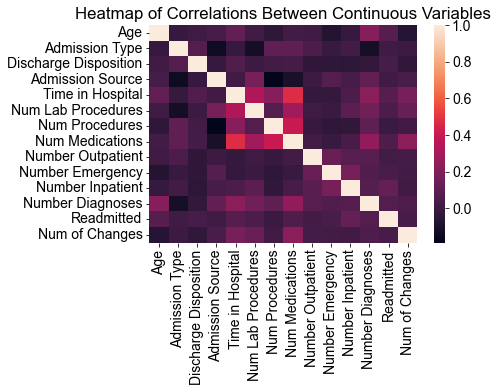

heatmap_continuous-4.png

#### 11.6.2 Appendix B Figure 2: Time Spent in Hospital vs. Readmission

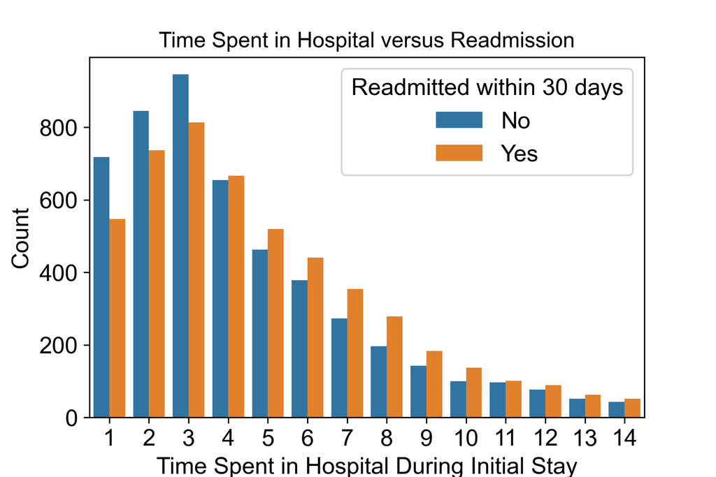

time_in_hospital_vs_readmissions-2.png

#### 11.6.3 Appendix B Figure 3: Number of Diagnoses vs. Readmission

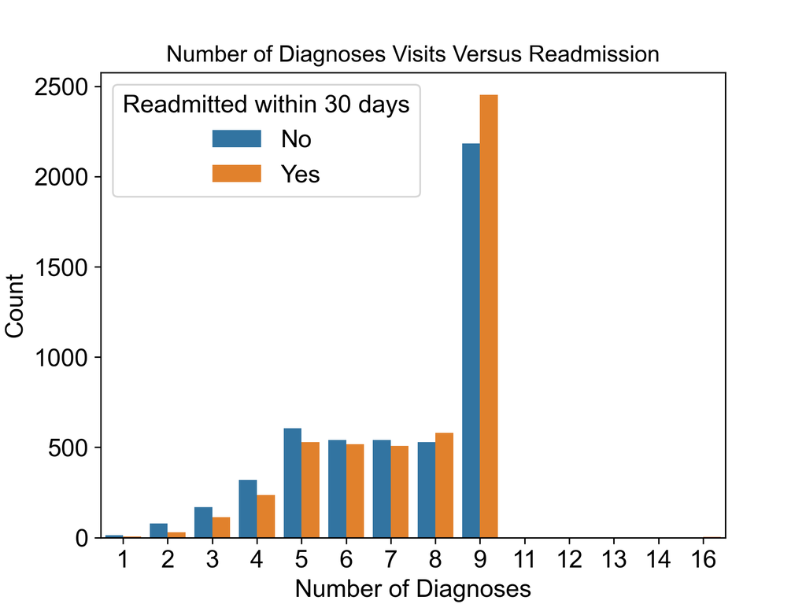

diag_vs_readmissions.png

#### 11.6.4 Appendix B Figure 4: Patient Age vs. Readmission

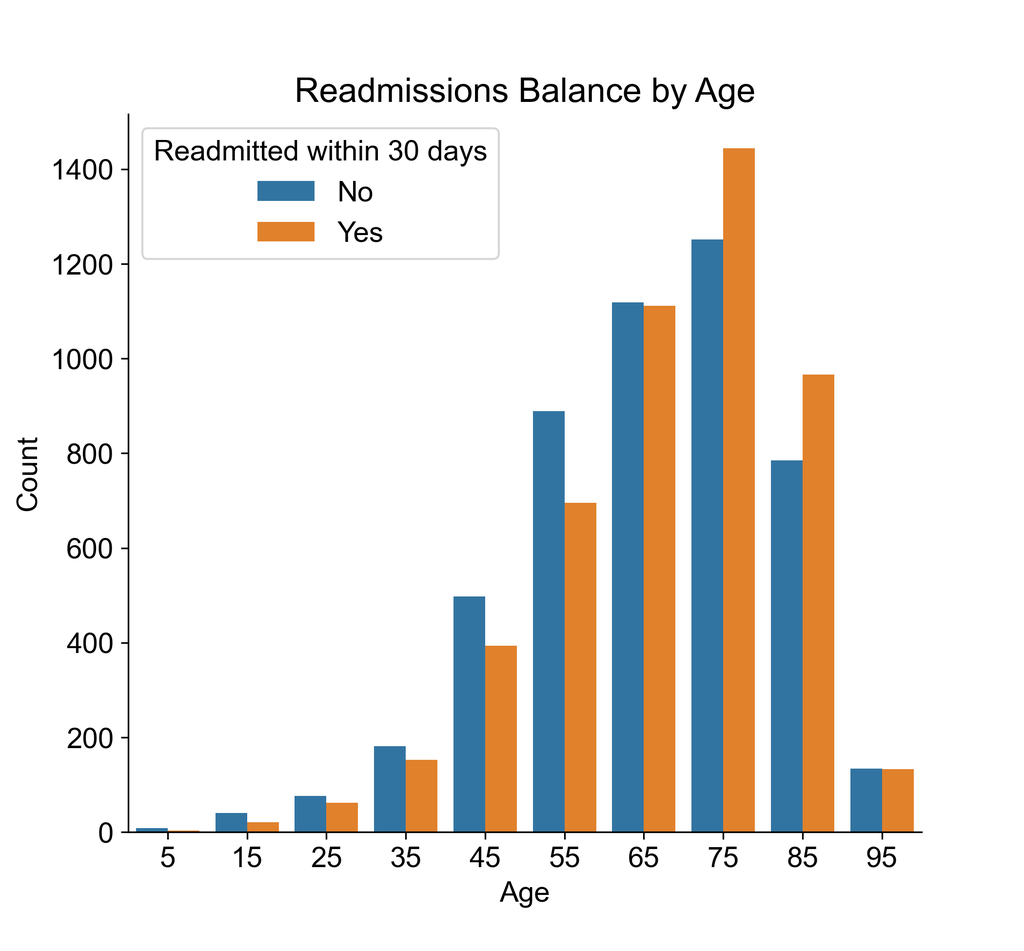

readmissions_vs_age.png

#### 11.6.5 Appendix B Figure 5: Number of Inpatient Visits vs. Readmission

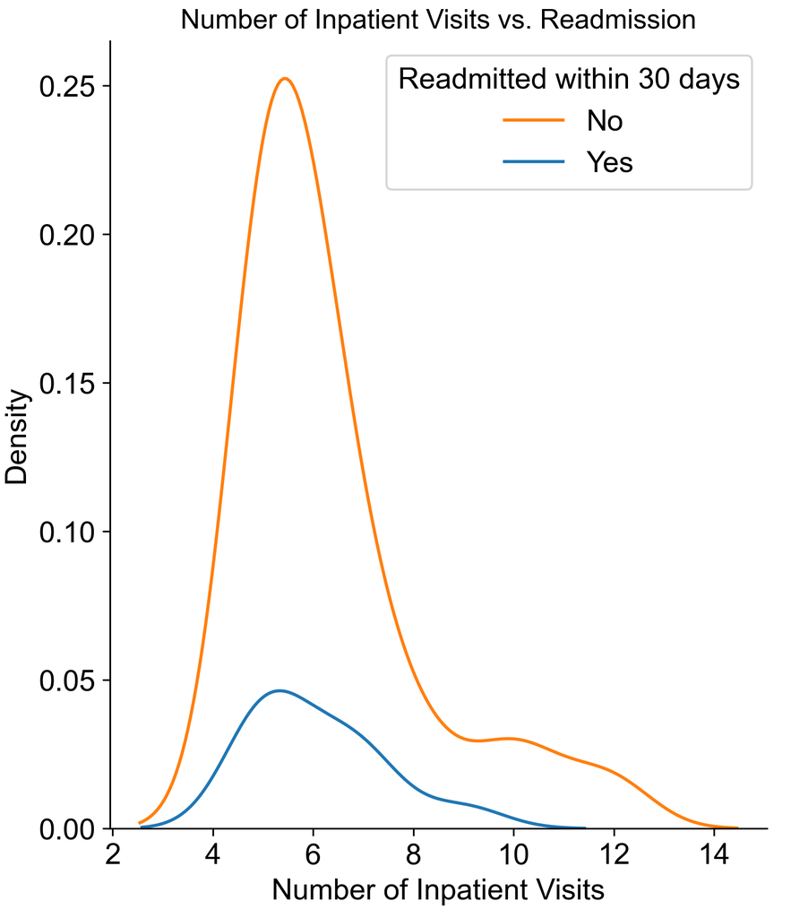

num_inpatient_vs_readmissions-3.png

#### 11.6.6 Appendix B Figure 6: Number of Emergency Visits vs. Readmission

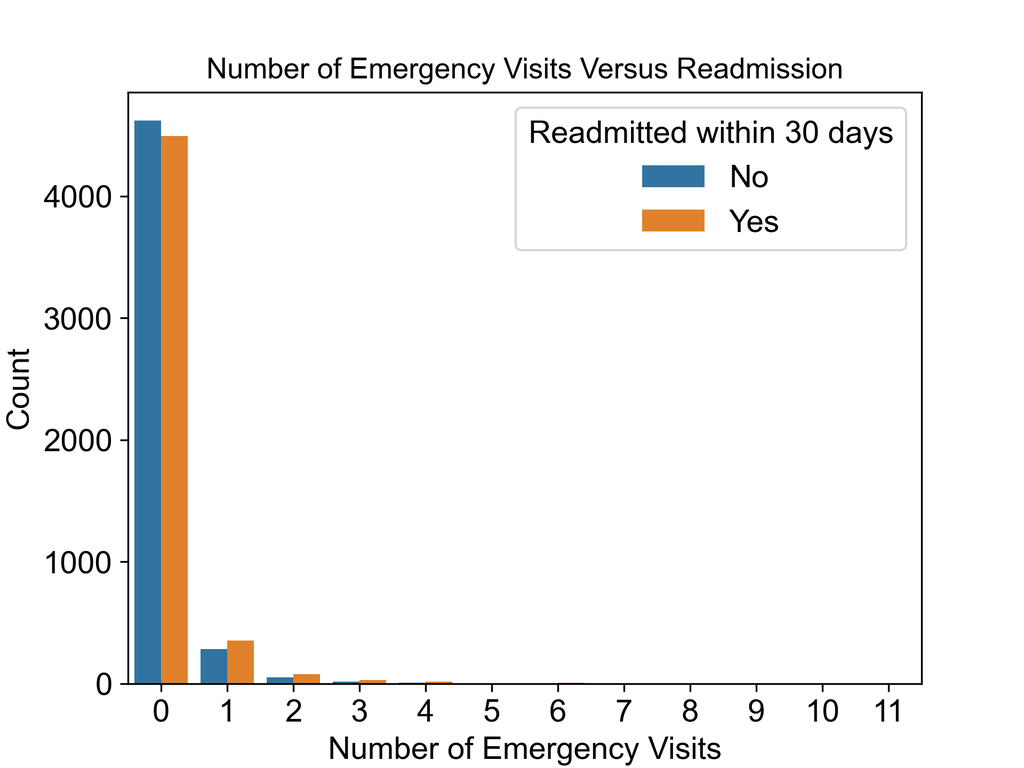

num_emergency_vs_readmissions.png

#### 11.6.7 Appendix B Figure 7: Number of Medication Changes vs. Readmission

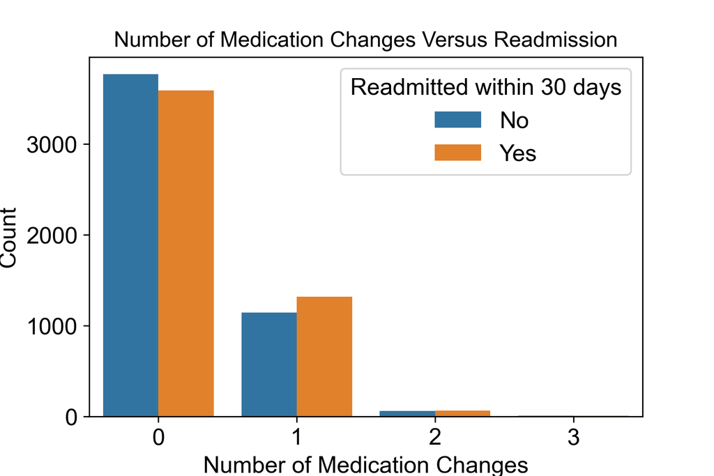

num_changes_vs_readmissions.png

#### 11.6.8 Appendix B Figure 8: Time Spent in Hospital vs. Patient Age

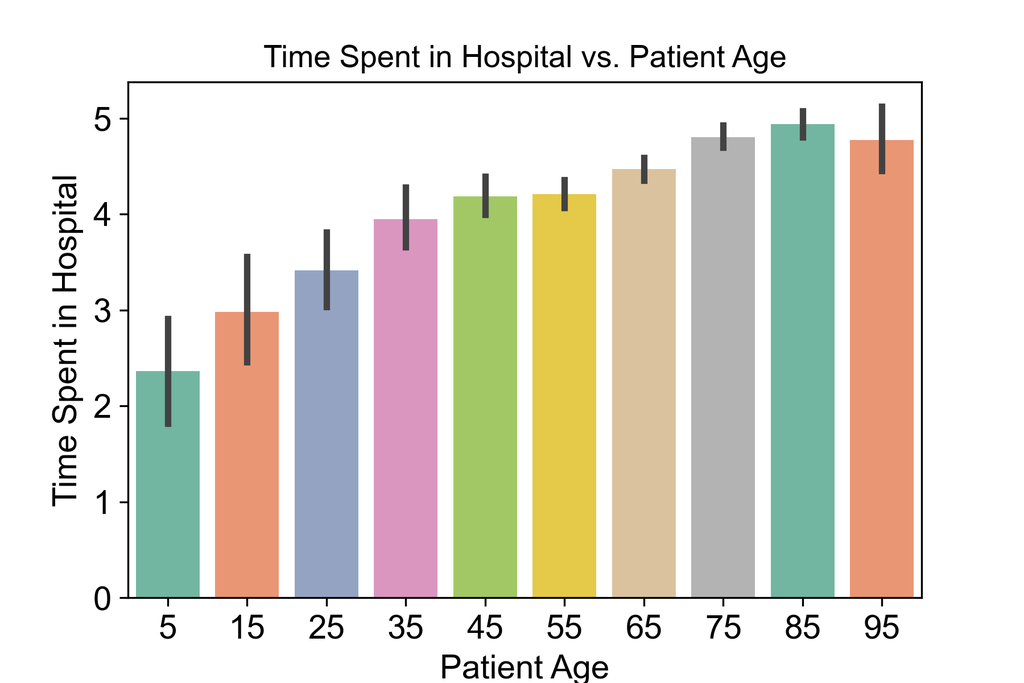

time_in_hospital_vs_age.png

#### 11.6.9 Appendix B Figure 9: Time Spent in Hospital vs. Number of Medication Changes

[figure not shown]

time_in_hospital_vs_num_changes.png

#### 11.6.10 Appendix B Figure 10: Number of Medication Changes vs. Number of Inpatient Visits

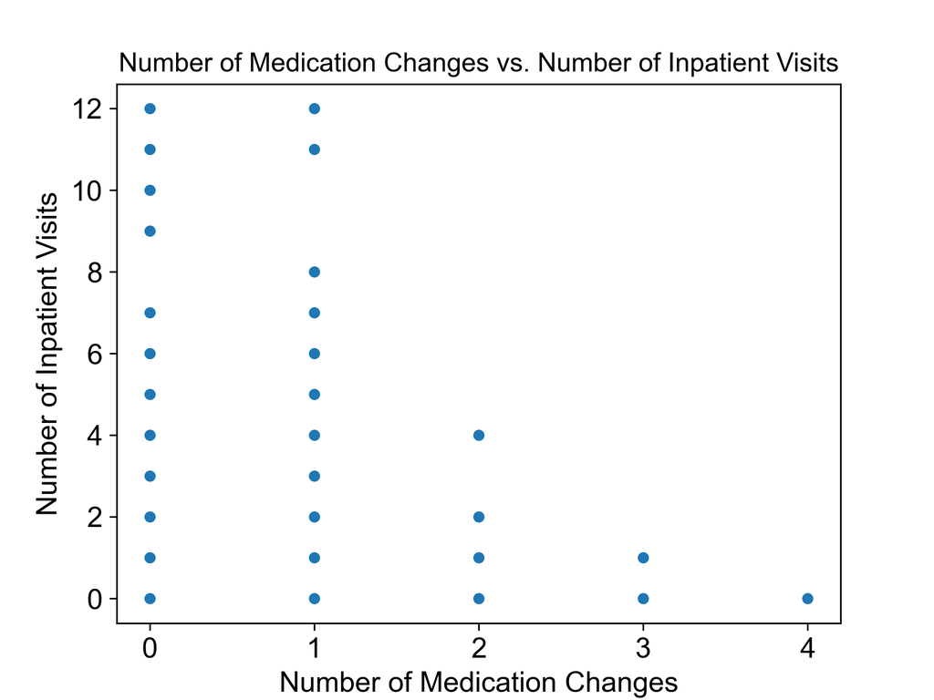

num_changes_vs_number_inpatient.png

#### 11.6.11 Appendix B Figure 11: Number of Inpatient Visits vs. Patient Age

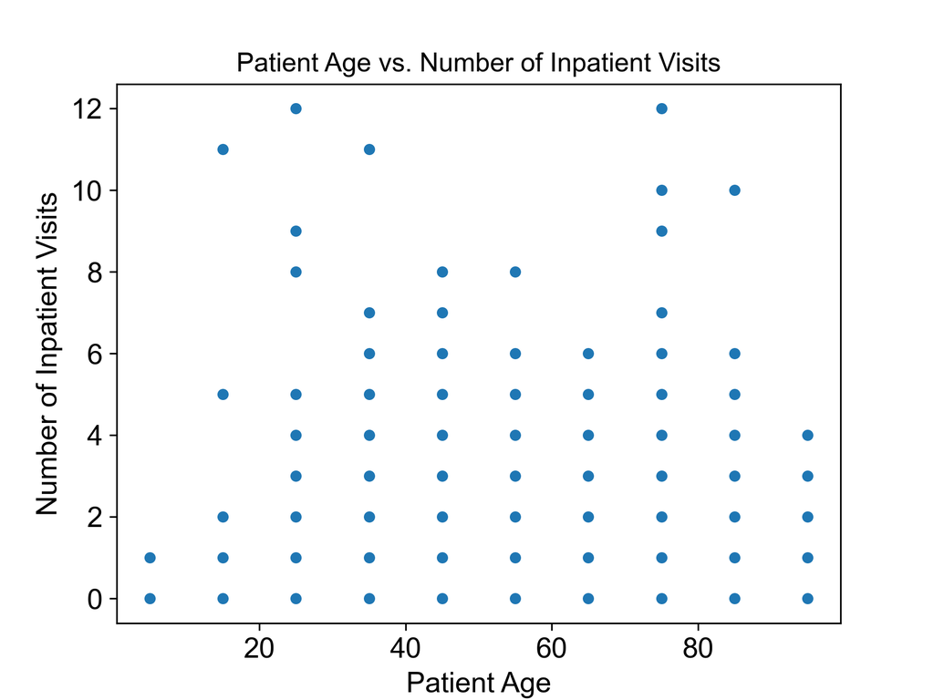

number_inpatient_vs_age.png

#### 11.6.12 Appendix B Figure 12: Number of Medication Changes vs. Patient Age

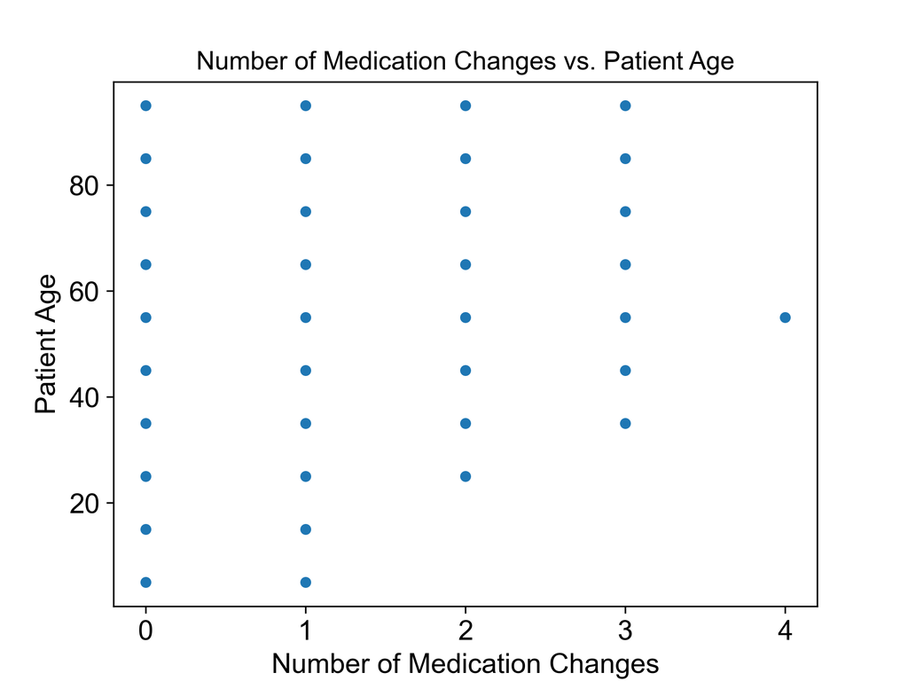

num_changes_vs_age.png

#### 11.6.13 Appendix B Figure 13: Number of Inpatient Visits vs. Time Spent in Hospital

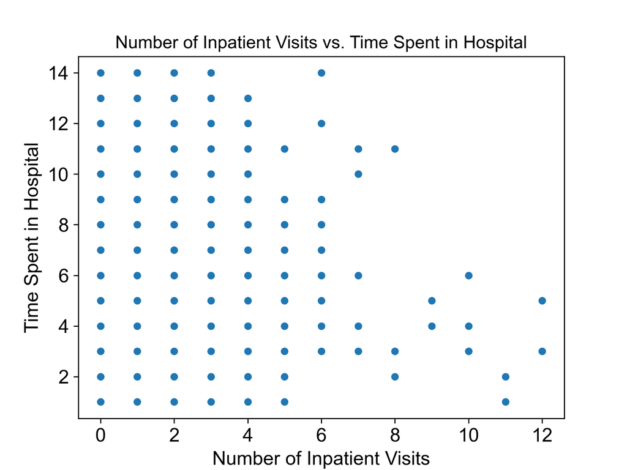

num_inpatient_vs_time_in_hospital.png

### 11.7 Appendix C: Approach

This appendix contains several figures related to our model approach. See each figure below for more detail.

#### 11.7.1 Appendix C Figure 1: Distribution of the response variable `readmitted` before undersampling or SMOTENC in the training data.

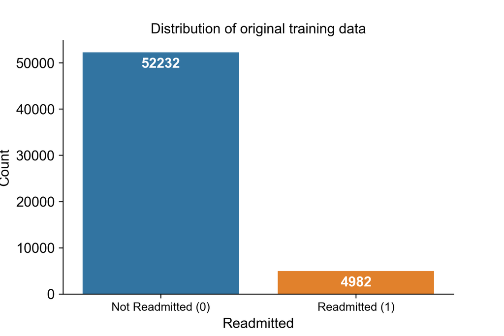

readmission_distribution_originaltrain.png

#### 11.7.2 Appendix C Figure 2: Distribution of the response variable `readmitted` after undersampling

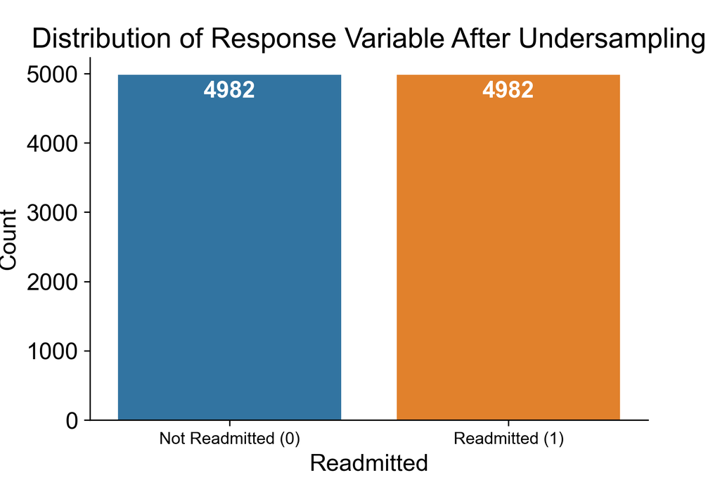

readmission_distribution_undersampling.png

#### 11.7.3 Appendix C Figure 3: Distribution of the response variable `readmitted` after SMOTENC

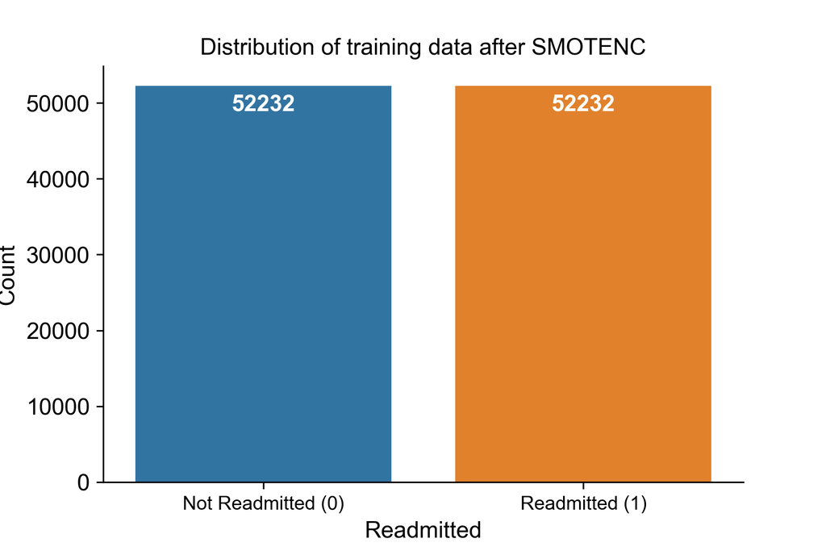

readmission_distribution_after_smotenc.png

#### 11.7.4 Appendix C Figure 4: Confusion Matrix of Base Model on Training Data

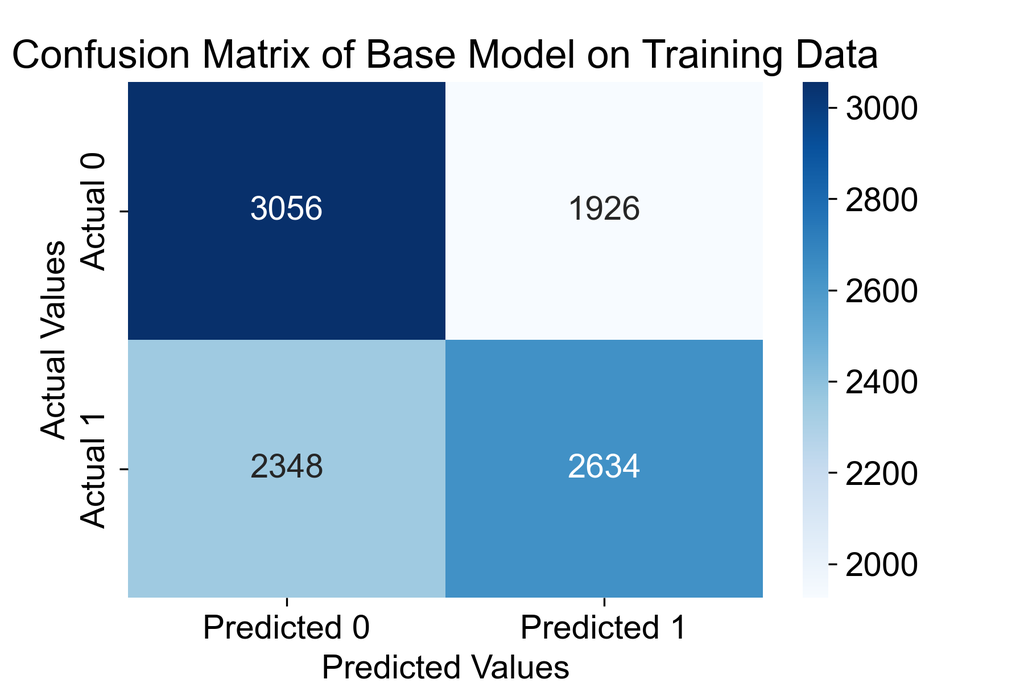

confusion_matrix_train-2.png

#### 11.7.5 Appendix C Figure 5: ROC Curve of Base Model

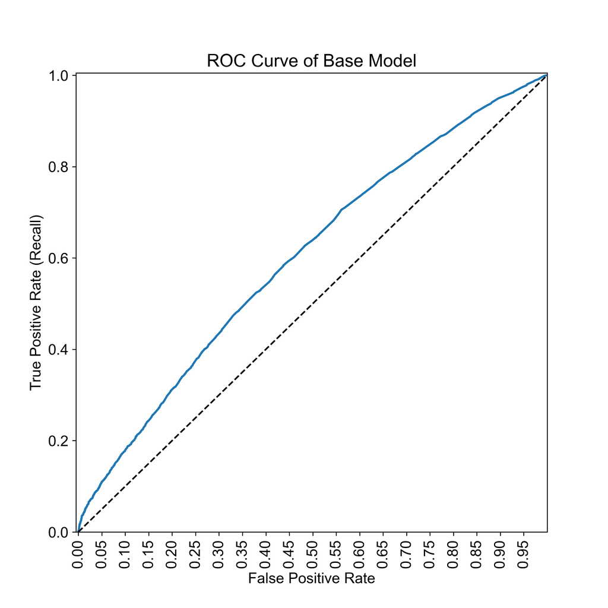

roc_curve_base_model.png

#### 11.7.6 Appendix C Figure 6: Confusion Matrix of Base Model on Test Data

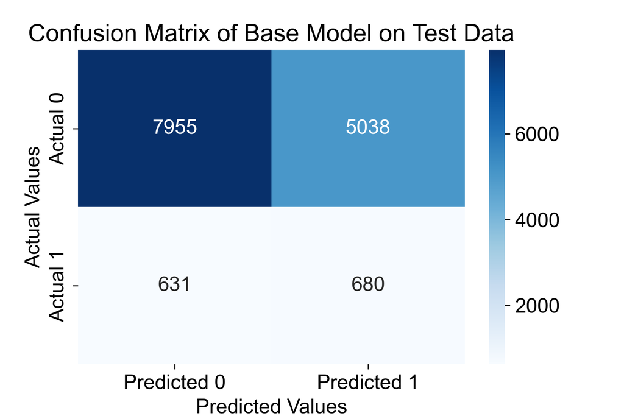

initial_confusion_matrix_test.png

#### 11.7.7 Appendix C Figure 7: Re-Trained Base Model Performance on Train Data (SMOTENC)

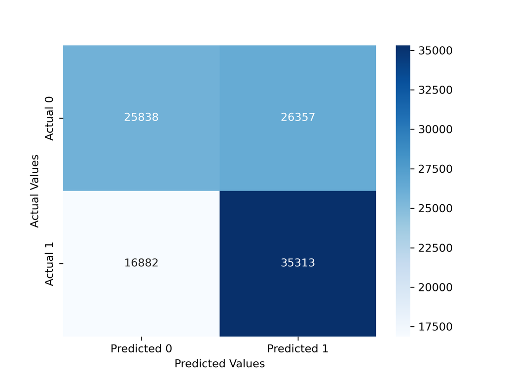

base_model_SMOTENC_train.png

#### 11.7.8 Appendix C Figure 8: Re-Trained Base Model Performance on Test Data

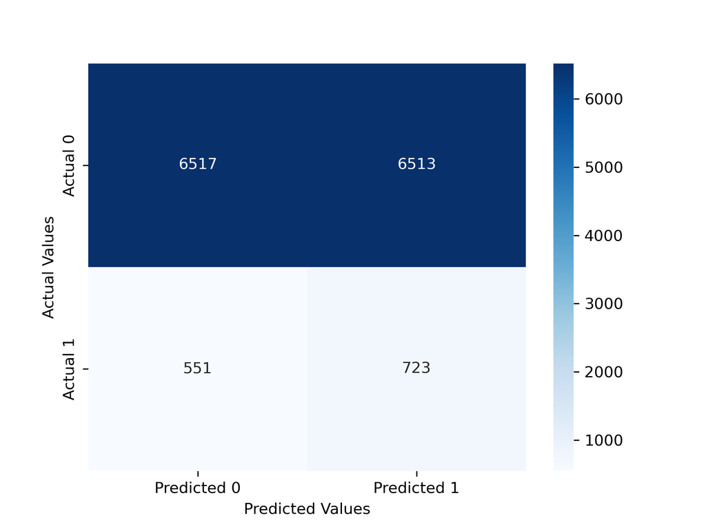

base_model_SMOTENC_test.png

#### 11.7.9 Appendix C Figure 9: Sharma’s Model Performance

Note, this figure was downloaded from Abishek Sharma’s code repository on Kaggle. The citation is listed under [5] in the references section of this report.

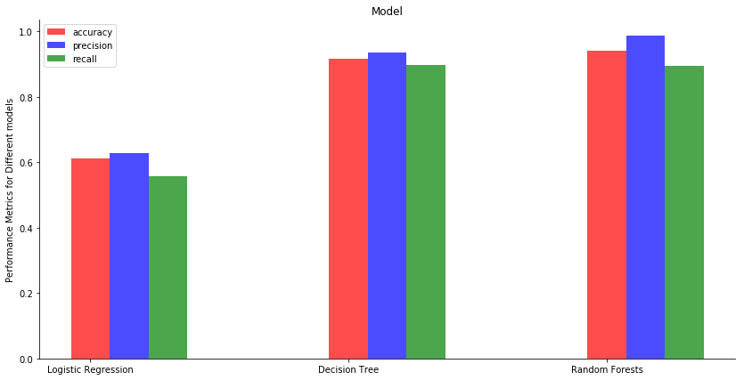

### 11.8 Appendix D: Developing the Model

This appendix contains several figures related to developing our optimized model. See each figure below for more detail.

**Appendix D Figure 1: Model 1.1, Age Bins as their own variable**  
Model Performance on Train Data

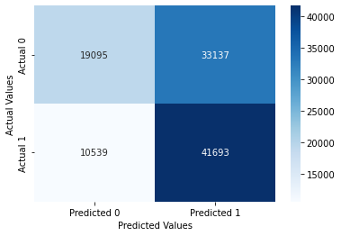

Classification accuracy = 58.2%  
Precision = 55.7%  
TPR or Recall = 79.8%  
FNR = 20.2%  
FPR = 63.4%  
ROC-AUC = 60.5%

Model Performance on Test Data

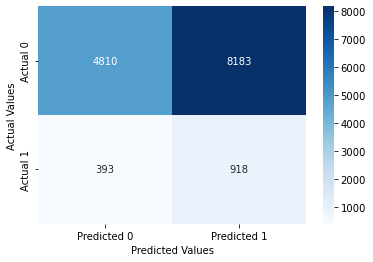

Classification accuracy = 40.0%  
Precision = 10.1%  
TPR or Recall = 70.0%  
FNR = 30.0%  
FPR = 63.0%  
ROC-AUC = 53.9%

**Appendix D Figure 2: Single Best Model**

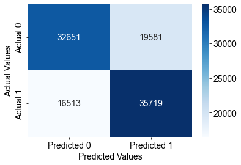

Classification accuracy = 65.4%  
Precision = 64.6%  
TPR or Recall = 68.4%  
FNR = 31.6%  
FPR = 37.5%  
ROC-AUC = 70.7%

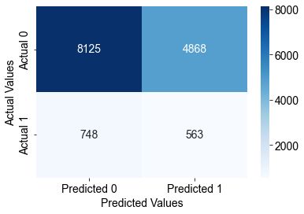

Classification accuracy = 60.7%  
Precision = 10.4%  
TPR or Recall = 42.9%  
FNR = 57.1%  
FPR = 37.5%  
ROC-AUC = 54.4%

**Appendix D Figure 3: Sklearn Feature Selection**  
Model Performance on Train Data

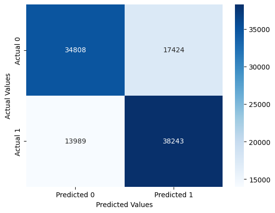

Model Performance on Test Data

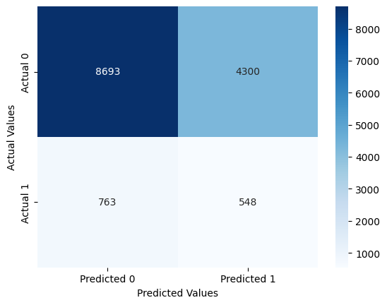

**Appendix D Figure 4: Sklearn Feature Interaction Selection**  
Model Performance on Train Data

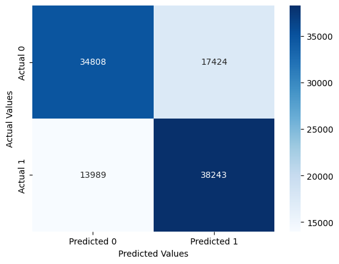

Classification accuracy = 69.9%  
Precision = 68.7%  
TPR or Recall = 73.2%  
FNR = 26.8%  
FPR = 33.4%  
ROC-AUC = 69.9%

Model Performance on Test Data

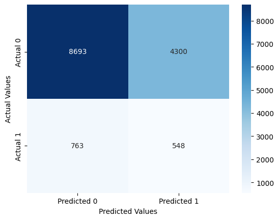

Classification accuracy = 64.6%  
Precision = 11.3%  
TPR or Recall = 41.8%  
FNR = 58.2%  
FPR = 33.1%  
ROC-AUC = 54.4%